# Google Review

Geetha

October 3, 2018

# Google Apps - User Rating

## Introduction

The list provides details on the ratings provided for different apps. It provides details on the the number of installations, reviews, Categories, Content rating etc.

We load the necessary libraries and check on the file details.

```r
library(ggplot2)
library(dplyr)
library(tidyverse)
library(lubridate)
library(plotly)
library(corrplot)
library(plyr)
options(scipen=999)

setwd("C:/Geetha/Kaggle/Google Store")

file <- read.csv("googleplaystore.csv")
file_review <- read.csv("googleplaystore_user_reviews.csv")
str(file)
```

```
## 'data.frame':    10841 obs. of  13 variables:
##  $ App           : Factor w/ 9660 levels "- Free Comics - Comic Apps",..: 7229 2563 8998 8113 7294 7125 8171 5589 4948 5826 ...
##  $ Category      : Factor w/ 34 levels "1.9","ART_AND_DESIGN",..: 2 2 2 2 2 2 2 2 2 2 ...
##  $ Rating        : num  4.1 3.9 4.7 4.5 4.3 4.4 3.8 4.1 4.4 4.7 ...
##  $ Reviews       : Factor w/ 6002 levels "0","1","10","100",..: 1183 5924 5681 1947 5924 1310 1464 3385 816 485 ...
##  $ Size          : Factor w/ 462 levels "1,000+","1.0M",..: 55 30 368 102 64 222 55 118 146 120 ...
##  $ Installs      : Factor w/ 22 levels "0","0+","1,000,000,000+",..: 8 20 13 16 11 17 17 4 4 8 ...
##  $ Type          : Factor w/ 4 levels "0","Free","NaN",..: 2 2 2 2 2 2 2 2 2 2 ...
##  $ Price         : Factor w/ 93 levels "$0.99","$1.00",..: 92 92 92 92 92 92 92 92 92 92 ...
##  $ Content.Rating: Factor w/ 7 levels "","Adults only 18+",..: 3 3 3 6 3 3 3 3 3 3 ...
##  $ Genres        : Factor w/ 120 levels "Action","Action;Action & Adventure",..: 10 13 10 10 12 10 10 10 10 12 ...
##  $ Last.Updated  : Factor w/ 1378 levels "1.0.19","April 1, 2016",..: 562 482 117 825 757 901 76 726 1317 670 ...
##  $ Current.Ver   : Factor w/ 2834 levels "","0.0.0.2","0.0.1",..: 121 1020 466 2827 279 115 279 2393 1457 1431 ...
##  $ Android.Ver   : Factor w/ 35 levels "","1.0 and up",..: 17 17 17 20 22 10 17 20 12 17 ...
```

```r
summary(file)
```

```
##                                                 App
##  ROBLOX                                           :    9
##  CBS Sports App - Scores, News, Stats & Watch Live:    8
##  8 Ball Pool                                      :    7
##  Candy Crush Saga                                 :    7
##  Duolingo: Learn Languages Free                   :    7
##  ESPN                                             :    7
##  (Other)                                          :10796
##          Category        Rating          Reviews
##  FAMILY      :1972   Min.   : 1.000   0      : 596
##  GAME        :1144   1st Qu.: 4.000   1      : 272
##  TOOLS       : 843   Median : 4.300   2      : 214
##  MEDICAL     : 463   Mean   : 4.193   3      : 175
##  BUSINESS    : 460   3rd Qu.: 4.500   4      : 137
##  PRODUCTIVITY: 424   Max.   :19.000   5      : 108
##  (Other)     :5535   NA's   :1474     (Other):9339
##                  Size             Installs      Type           Price
##  Varies with device:1695   1,000,000+ :1579   0   :    1   0      :10040
##  11M               : 198   10,000,000+:1252   Free:10039   $0.99  :  148
##  12M               : 196   100,000+   :1169   NaN :    1   $2.99  :  129
##  14M               : 194   10,000+    :1054   Paid:  800   $1.99  :   73
##  13M               : 191   1,000+     : 907                $4.99  :   72
##  15M               : 184   5,000,000+ : 752                $3.99  :   63
##  (Other)           :8183   (Other)    :4128                (Other):  316
##          Content.Rating           Genres             Last.Updated
##                 :   1   Tools        : 842   August 3, 2018: 326
##  Adults only 18+:   3   Entertainment: 623   August 2, 2018: 304
##  Everyone       :8714   Education    : 549   July 31, 2018 : 294
##  Everyone 10+   : 414   Medical      : 463   August 1, 2018: 285
##  Mature 17+     : 499   Business     : 460   July 30, 2018 : 211
##  Teen           :1208   Productivity : 424   July 25, 2018 : 164
##  Unrated        :   2   (Other)      :7480   (Other)       :9257
##              Current.Ver               Android.Ver
##  Varies with device:1459   4.1 and up        :2451
##  1.0               : 809   4.0.3 and up      :1501
##  1.1               : 264   4.0 and up        :1375
##  1.2               : 178   Varies with device:1362
##  2.0               : 151   4.4 and up        : 980
##  1.3               : 145   2.3 and up        : 652
##  (Other)           :7835   (Other)           :2520
```

## Data Cleaning

Cleaning the data to make better analysis with the data.

```r
file$Reviews <- as.numeric(file$Reviews)# Review is numeric
file$Size <- gsub("M", "", file$Size)
file$Size <- ifelse(grepl("k", file$Size), as.numeric(file$Size)/1000, file$Size)
file$Installs <- as.character(file$Installs)
file$Installs <- gsub("\\+", "", file$Installs)#removes + and saves with "," as a character
file$Installs <- gsub(",", "", file$Installs)
file$Installs <- as.numeric(file$Installs)
file$Price <- as.numeric(gsub("\\$", "", as.character(file$Price)))
file$Size <- as.numeric(gsub("\\k", "", as.character(file$Size)))
```

## Feature Engineering

```r
file_1 <- file %>%
          filter(Category != 1.9)%>%#1.9 is removed
          filter(!is.na(Rating))%>%
          filter(!is.na(Size))%>%
          filter(!is.na(Reviews))%>%
          filter(!is.na(Installs))%>%
          filter()


file_1$rating_bin[file_1$Rating < 1] = "Less than 1"
file_1$rating_bin[file_1$Rating >= 1 & file_1$Rating <2] = "More than 1 and less than 2"
file_1$rating_bin[file_1$Rating >= 2 & file_1$Rating <3] = "More than 2 and less than 3"
file_1$rating_bin[file_1$Rating >= 3 & file_1$Rating <4] = "More than 3 and less than 4"
file_1$rating_bin[file_1$Rating >= 4] = "More than 4"
```

## Exploratory Data analysis

To make ourself familiar with the data, we perform the following analysis. We start our analysis from the category column.

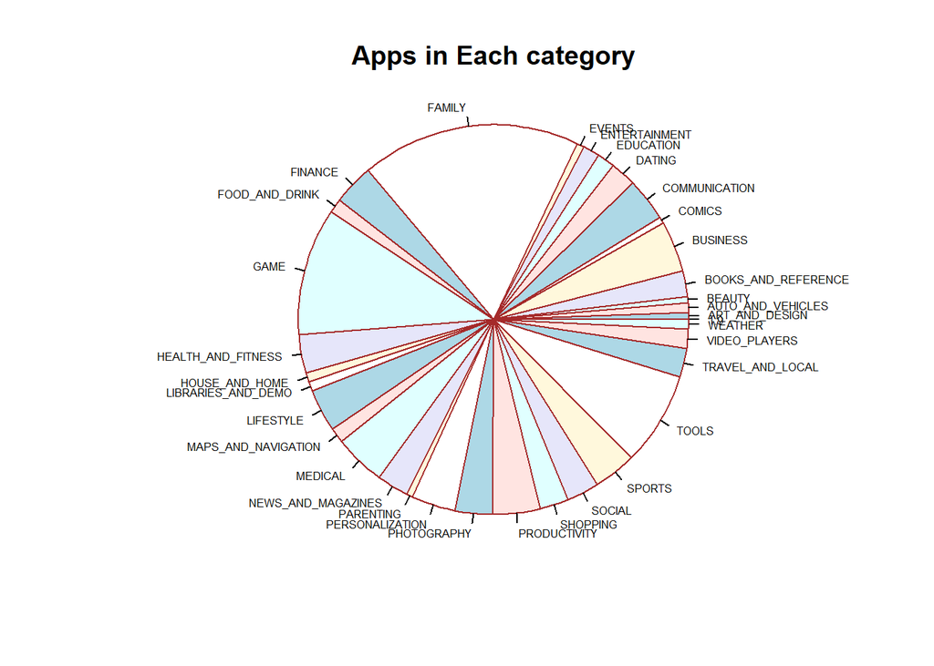

```r
pie(table(file$Category), main = "Apps in Each category", border = "brown", cex = .5, radius = 1)
```

Top3 categories based on number of apps - Family, Game and Tools

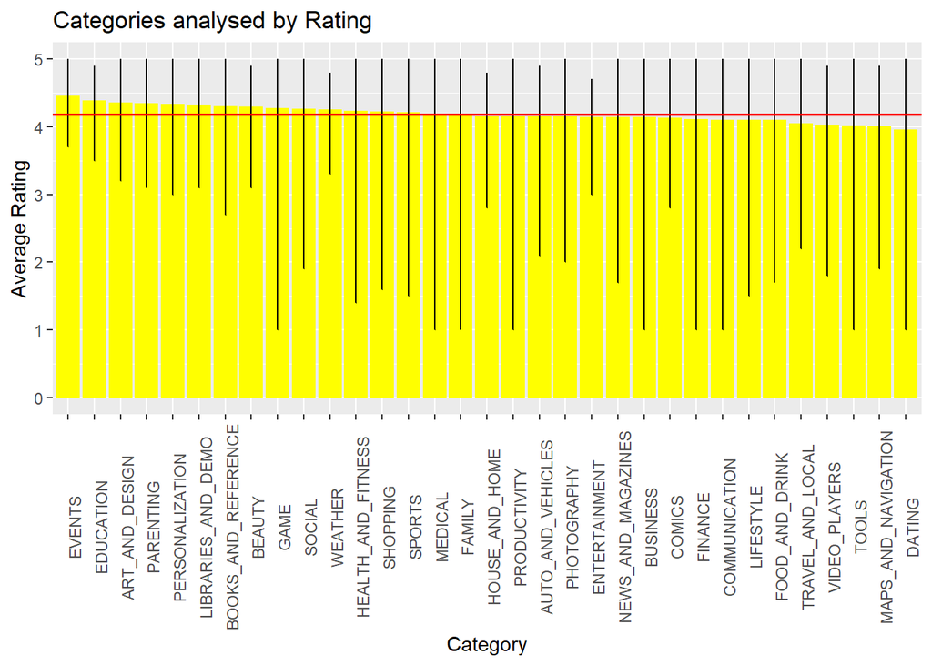

```r
mean_rating <- mean(file_1$Rating)

file_1$rating_bin[file_1$Rating < 1] = "Less than 1"
file_1$rating_bin[file_1$Rating >= 1 & file_1$Rating <2] = "More than 1 and less than 2"
file_1$rating_bin[file_1$Rating >= 2 & file_1$Rating <3] = "More than 2 and less than 3"
file_1$rating_bin[file_1$Rating >= 3 & file_1$Rating <4] = "More than 3 and less than 4"
file_1$rating_bin[file_1$Rating >= 4] = "More than 4"

file_1$rating_bin <- as.factor(file_1$rating_bin)


ggplot(file_1, aes(reorder(Category, -Rating, mean), Rating))+
  theme(axis.text.x = element_text(angle = 90))+
  stat_summary(fun.y = "mean", geom = "bar", fill = "yellow")+ xlab("Category")+ylab("Average Rating")+
  geom_line()+geom_hline(yintercept = mean_rating, color = "red")+
  labs(title = "Categories analysed by Rating")
```

Top3 categories based on rating of apps - Events, Education and Art and Design. The ratings for these 3 top apps have not gone below 3.However for game, family, medical, productivity, Business, Finance, communication, Tools and Dating the rating ranges from 1 to 5. Mean rating for the apps is 4.17. Out of 33 categories, average rating for 18 apps are below the total average.

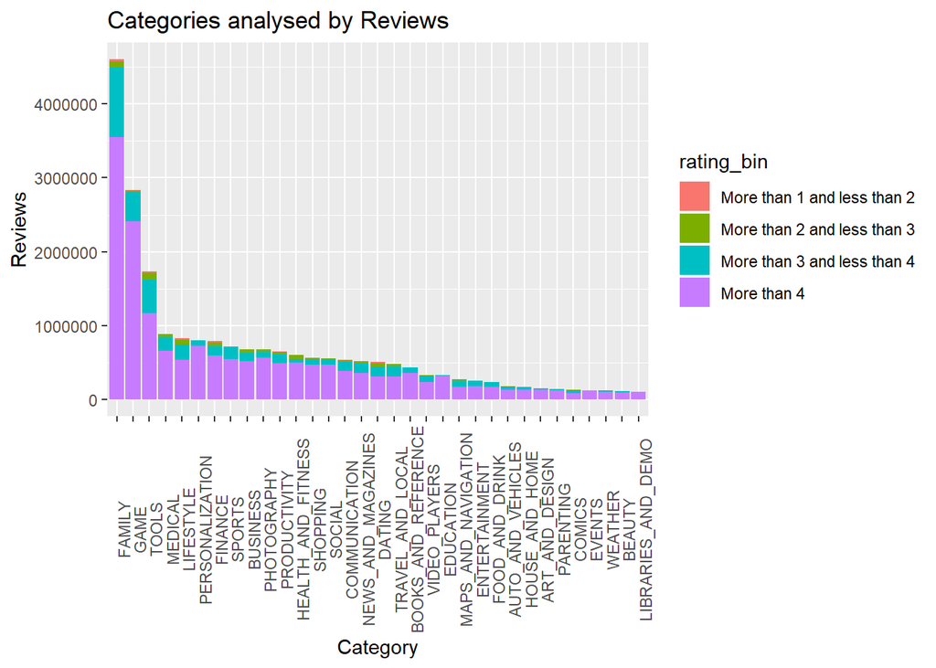

```r
ggplot(file_1, aes(reorder(Category, -Reviews, sum), Reviews, fill = rating_bin ))+geom_bar(stat = "identity")+
  theme(axis.text.x = element_text(angle = 90))+
  xlab("Category")+ylab("Reviews")+
  labs(title = "Categories analysed by Reviews")
```

Top3 categories based on number of reviews - Family, Game and tools

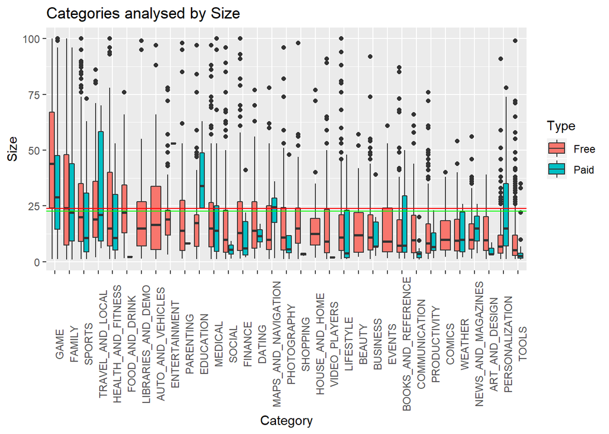

```r
mean_size_F <- file_1%>%
             filter(Type == "Free")%>%
            summarise(mean = mean(Size))

mean_size_P <- file_1%>%
              filter(Type == "Paid")%>%
              summarise(mean = mean(Size))

ggplot(file_1, aes(reorder(Category, -Size), Size, fill = Type ))+
  theme(axis.text.x = element_text(angle = 90))+
  geom_boxplot()+ xlab("Category")+ylab("Size")+
  geom_hline(yintercept = mean_size_F$mean, color = "red")+
  geom_hline(yintercept = mean_size_P$mean, color = "green")+
  labs(title = "Categories analysed by Size")
```

Categories are listed based on the average size of the apps. Average size is higher for Games, Family and Sports. In few apps like Dating, LIbraries and Demo, though the average size is less, they have apps with very huge size. The number of ouliers are more in Free apps compared to paid apps. The average sie of Free app is 23.83, while the average size of a paid app is 22.58

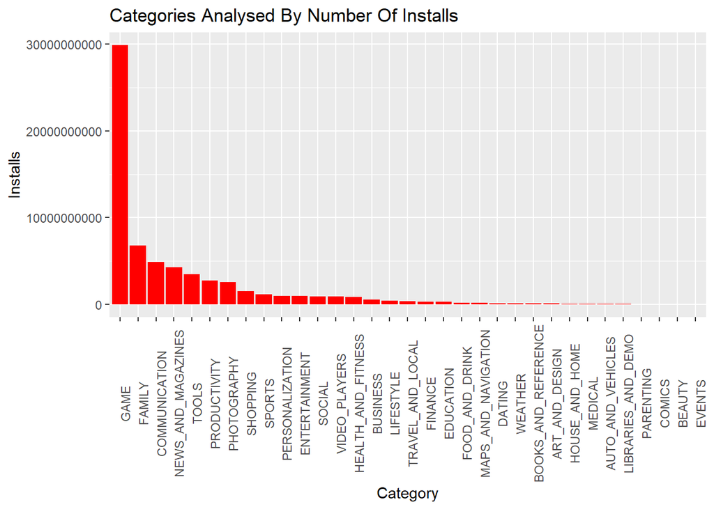

```r
ggplot(file_1, aes(reorder(Category, -Installs, sum), Installs))+
  theme(axis.text.x = element_text(angle = 90))+
  geom_bar(stat = "identity", fill = "red")+ xlab("Category")+ylab("Installs")+
  labs(title = "Categories Analysed By Number Of Installs")
```

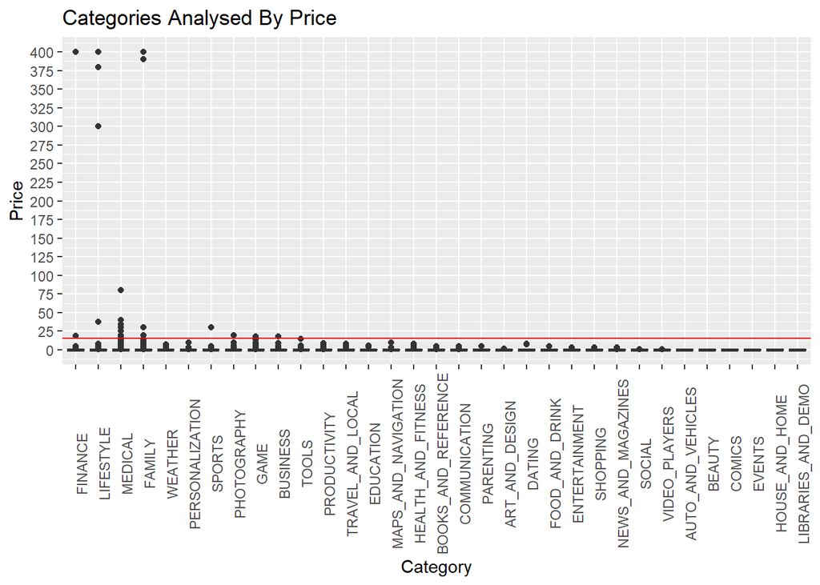

```r
mean_price <- file_1%>%
              filter(Type == "Paid")%>%
              summarise(mean = mean(Price))


ggplot(file_1, aes(reorder(Category, -Price), Price))+
  theme(axis.text.x = element_text(angle = 90))+
  geom_boxplot()+
  scale_y_continuous(breaks = seq(0,400,25), limits = c(0,400))+
  xlab("Category")+ylab("Price")+
  geom_hline(yintercept = mean_price$mean, color = "red")+
  labs(title = "Categories Analysed By Price")
```

Finance, Lifestyle and Family has apps costing around 400 dollars where the mean price of all paid app is $15.05

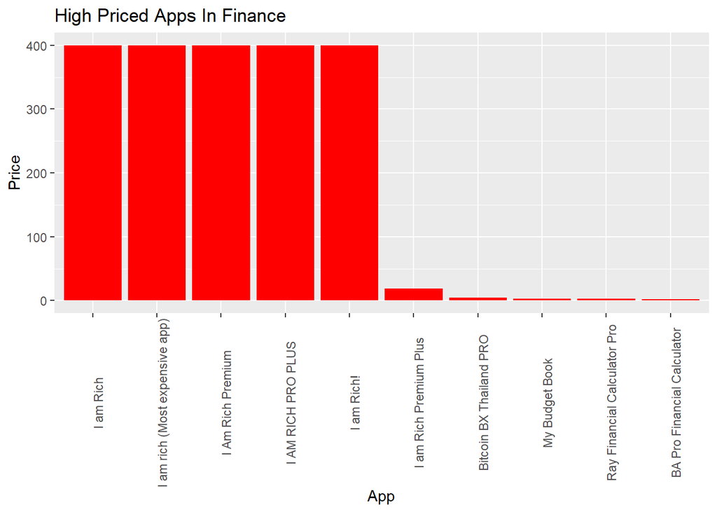

```r
fin <- file_1 %>%
       filter(Type == "Paid")%>%
       filter(Category == "FINANCE")

ggplot(fin, aes(reorder(App, -Price, mean), Price))+
  theme(axis.text.x = element_text(angle = 90))+
  geom_bar(stat = "identity", fill = "red")+ xlab("App")+ylab("Price")+
  labs(title = "High Priced Apps In Finance")
```

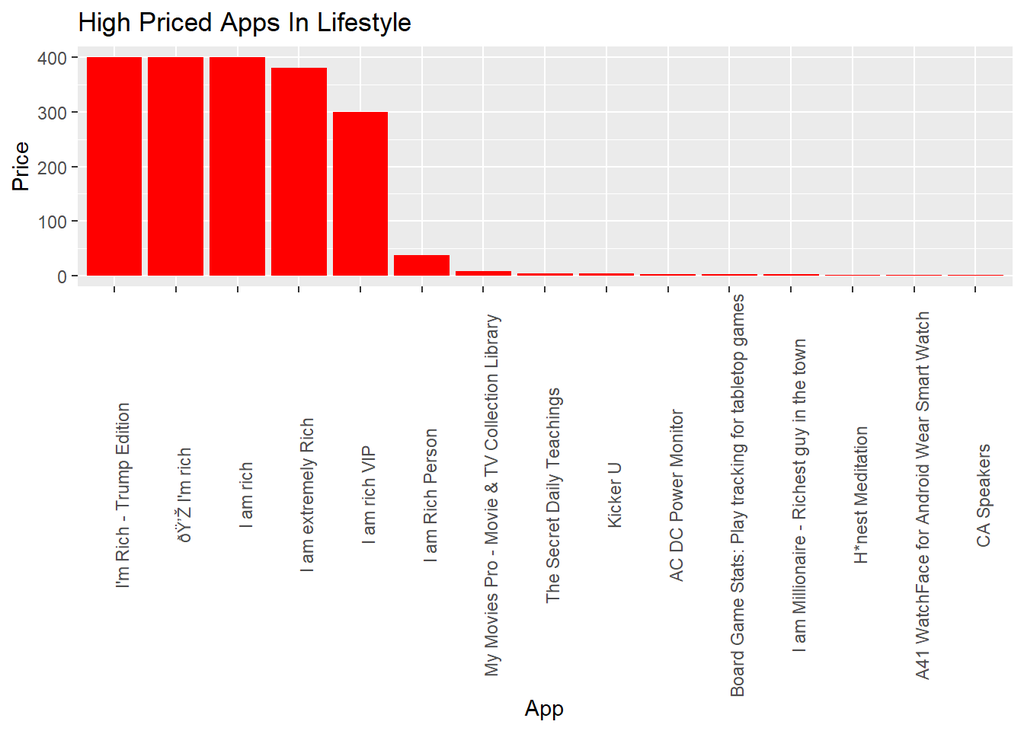

```r
lif <- file_1 %>%
  filter(Type == "Paid")%>%
  filter(Category == "LIFESTYLE")

ggplot(lif, aes(reorder(App, -Price, mean), Price))+
  theme(axis.text.x = element_text(angle = 90))+
  geom_bar(stat = "identity", fill = "red")+ xlab("App")+ylab("Price")+
  labs(title = "High Priced Apps In Lifestyle")
```

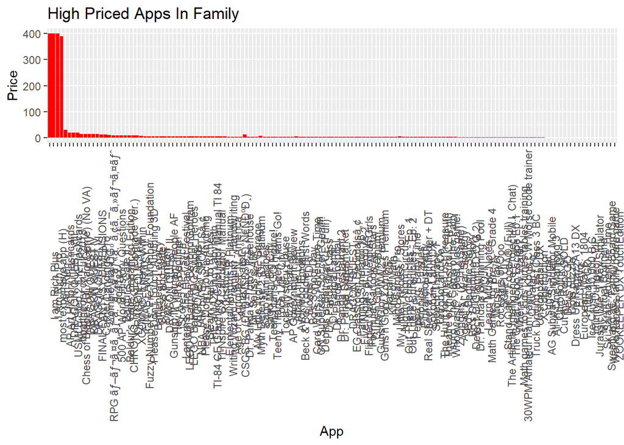

```r
fam <- file_1 %>%
  filter(Type == "Paid")%>%
  filter(Category == "FAMILY")

ggplot(fam, aes(reorder(App, -Price, mean), Price))+
  theme(axis.text.x = element_text(angle = 90))+
  geom_bar(stat = "identity", fill = "red")+ xlab("App")+ylab("Price")+
  labs(title = "High Priced Apps In Family")
```

The apps with high Price are listed in these charts. The number of paid apps are more in Family comparede to other two highly priced Categories.

## Rating Analysis

We will now analyse to see the factors that impact the rating of an app.

In the below steps, Rating is analysed with Reviews, Size, Install and Price to identify whether are there any correlation between these factors.

```r
file_2 <- subset(file_1, select = c("Rating", "Reviews", "Size", "Installs", "Price"))
C <- cor(file_2)
C
```

```
##                Rating      Reviews         Size    Installs        Price
## Rating    1.000000000 -0.004831708  0.075788143  0.05188592 -0.018733201
## Reviews  -0.004831708  1.000000000  0.001213443  0.02136758  0.006081288
## Size      0.075788143  0.001213443  1.000000000  0.16016617 -0.025464956
## Installs  0.051885923  0.021367575  0.160166172  1.00000000 -0.010839684
## Price    -0.018733201  0.006081288 -0.025464956 -0.01083968  1.000000000
```

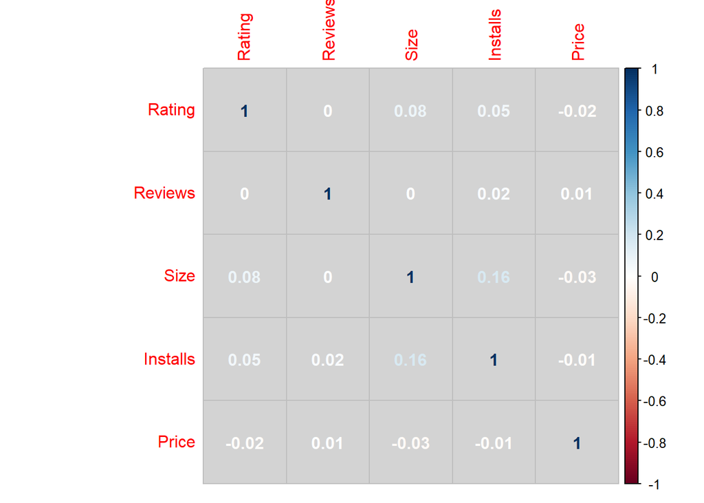

```r
corrplot(C, method = "number", bg="lightgray")
```

Ratings are positively correlated with Installs(0.05) and Size (0.08) and negatively correlated with Price(-0.019) and Reviews(-0.0048)

### Rating and Installs

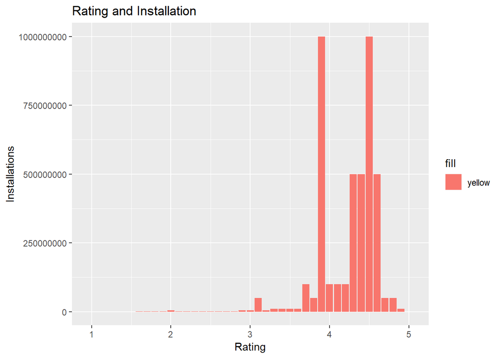

```r
perc <- ddply(file_1, .(file_1$Installs, file_1$Type, file_1$Rating), nrow)
names(perc) <- c("Installs", "Type", "Rating", "Count")
perc_ins <- perc%>%
            group_by(Installs)%>%
            group_by(Type)%>%
            mutate(perc = (Count / sum(Count))*100)


ggplot(perc_ins, aes(x = Rating, y = Installs, fill = "yellow"))+geom_bar(stat = "identity", position = "dodge")+  xlab("Rating")+ylab("Installations")+ labs(title = "Rating and Installation")
```

From the graph it is clear that the rating is high when the installations are more.

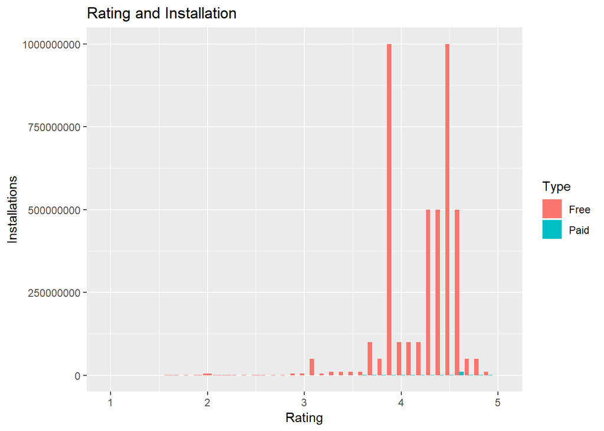

```r
ggplot(perc_ins, aes(x = Rating, y = Installs, fill = Type))+geom_bar(stat = "identity", position = "dodge")+  xlab("Rating")+ylab("Installations")+ labs(title = "Rating and Installation")
```

### Rating and Size

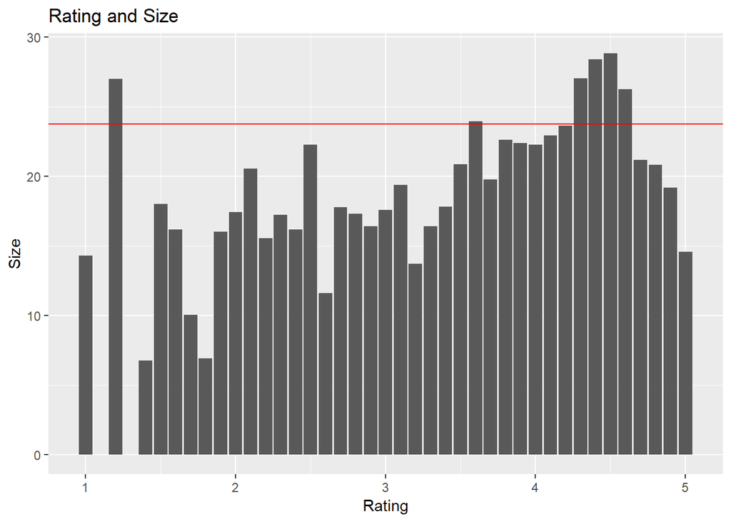

```r
mean_size <- file_1%>%
  summarise(mean = mean(Size))

ggplot(file_1, aes(x = Rating, y = Size))+
  stat_summary(fun.y = "mean", geom = "bar", position = "dodge")+xlab("Rating")+
  ylab("Size")+ labs(title = "Rating and Size")+geom_hline(yintercept = mean_size$mean, color = "red")
```

# Rating and Price

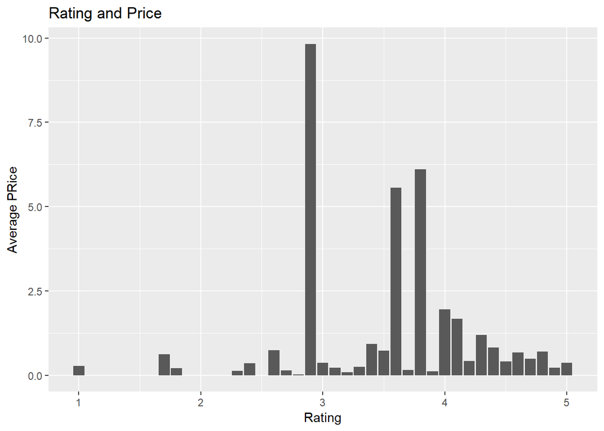

```r
ggplot(file_1, aes(x = Rating, y= Price))+stat_summary(fun.y = "mean", geom = "bar")+
  xlab("Rating")+ylab("Average PRice")+ labs(title = "Rating and Price")
```

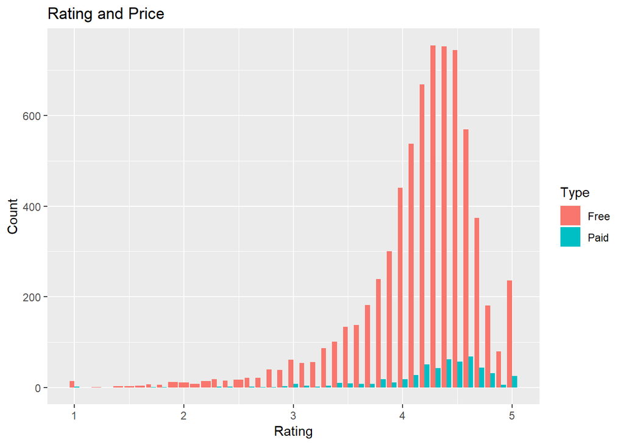

```r
ggplot(file_1, aes(x = Rating, fill = Type))+geom_bar(stat = "Count", position = "dodge")+xlab("Rating")+ylab("Count")+ labs(title = "Rating and Price")
```

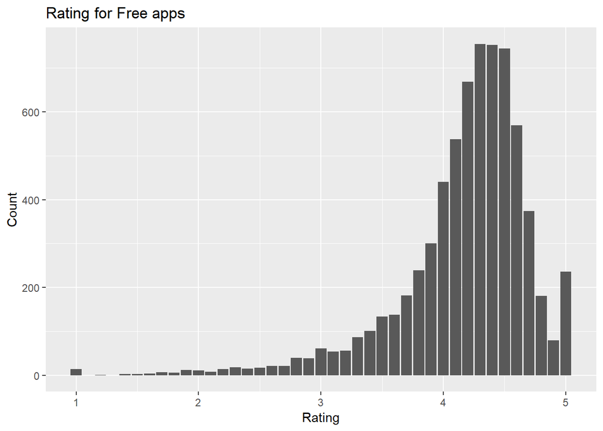

```r
free <- subset(file_1, Type == "Free")
ggplot(free, aes(x = Rating))+geom_bar(stat = "Count")+xlab("Rating")+ylab("Count")+ labs(title = "Rating for Free apps")
```

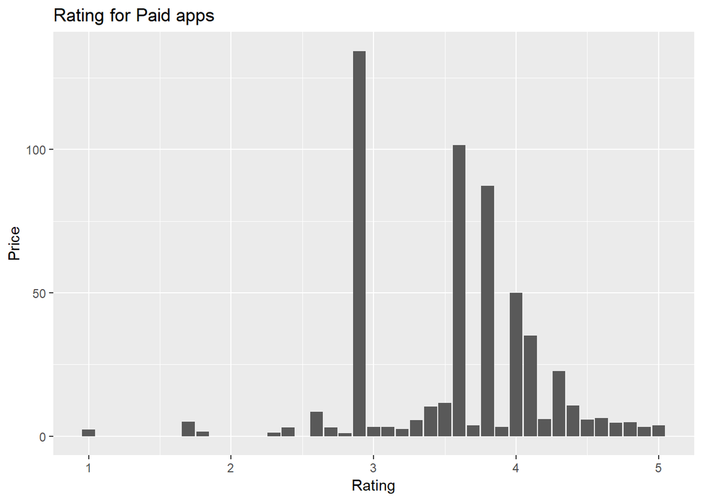

```r
paid <- subset(file_1, Type == "Paid")
ggplot(paid, aes(x = Rating, y = Price))+stat_summary(fun.y = "mean", geom = "bar")+xlab("Rating")+ylab("Price")+ labs(title = "Rating for Paid apps")
```